# HTML report compare data matrix

Jishu Xu

30 May, 2018

# Purpose

In this section, we will compare two pipeline output by their clustering results. The data we use to do the clustering analysis is the TPM output from each pipeline. We use SNN-Cliq method to cluster this single cell TPM data and then compare clustering results with data metadata, such as known cell type and cell lineage. The adjust RAND index is calculated for each pipeline. In thoery, higher RAND index indicate more similiarity between clustering results and known cell labels.

# Input data

The key input data for this test are the data matrix generated by two pipelines, they can be gene counts matrix or TPM, FPKM matrix. The detail of input data are listed below

- matrix1: data matrix from pipeline, such as base pipeline.
- matrix2: data matrix from pipeline, such as updated pipeline.
- metadata_file: meta information about cells, such as cell type.
- output_prefix: output prefix or output name.

First load functions we will use in this test

```r
source('analysis_functions.R')
set.seed(42)
```

Here is the list of input parameters

```r
option_list <- list(
  make_option(
    "--matrix1",
    type = "character",
    default = NULL,
    help = "data matrix file name",
    metavar = "character"
  ),
  make_option(
    "--matrix2",
    type = "character",
    default = NULL,
    help = "updated data matrix file name",
    metavar = "character"
  ),
  make_option(
    "--metadata_file",
    type = "character",
    default = NULL,
    help = "sample metadata file",
    metavar = "character"
  ),
  make_option(
    "--output_prefix",
    type = "character",
    default = NULL,
    help = "output prefix",
    metavar = "character"
  ),
  make_option(
    "--metaKeys",
    type = "character",
    default = NULL,
    help = "the list of meta values to be considered as confounding factors",
    metavar = "character"
  )
)
args<-strsplit(commandArgs(trailingOnly = TRUE),split=' ')
opt_parser <- OptionParser(option_list = option_list)
opt <- parse_args(opt_parser,args=args[[1]])
matrixfile1 <- opt$matrix1
matrixfile2 <- opt$matrix2
meta_file <- opt$metadata_file
output_name <- opt$output_prefix
metaKeys <- strsplit(opt$metaKeys, split = ',')[[1]]
```

# Parse Inputs

## Metadata

metadata records information related to this dataset, such as ‘cell lineage’,‘celltype’,‘is population’

```r
# parse metadata
meta <- read.delim(meta_file, sep = ',', header = T)
knitr::kable(head(meta))
```

| sra | donor | source | cell | cellcounts | population |
| --- | --- | --- | --- | --- | --- |
| SRR5375300 | Donor 1 | CD8+ CMV-specific T cell donor 1 | CD8+ CMV-specific T cell | 1 | sc |
| SRR5375302 | Donor 1 | CD8+ CMV-specific T cell donor 1 | CD8+ CMV-specific T cell | 1 | sc |
| SRR5375304 | Donor 1 | CD8+ CMV-specific T cell donor 1 | CD8+ CMV-specific T cell | 1 | sc |
| SRR5375306 | Donor 1 | CD8+ CMV-specific T cell donor 1 | CD8+ CMV-specific T cell | 1 | sc |
| SRR5375308 | Donor 1 | CD8+ CMV-specific T cell donor 1 | CD8+ CMV-specific T cell | 1 | sc |
| SRR5375310 | Donor 1 | CD8+ CMV-specific T cell donor 1 | CD8+ CMV-specific T cell | 1 | sc |

## Load Data Matrix

Data matrix files are *.csv file and can be count, TPM or FPKM matrix. For benchmarking purpose, TPM would be optimal choice.

```r
# load matrix file
mat1 <- read.csv(matrixfile1)
mat2 <- read.csv(matrixfile2)
rownames(mat1) <- mat1[, 1]
rownames(mat2) <- mat2[, 1]
mat1.d <- mat1[, -c(1:2)]
mat2.d <- mat2[, -c(1:2)]
```

Match row and column between two matrix

```r
# match row
mlist <- match(rownames(mat1.d), rownames(mat2.d))
# match sample column
nlist <- match(colnames(mat1.d), colnames(mat2.d))
mat2.d <- mat2.d[mlist, nlist]
```

## Data Transformation Take log2 transformation

```r
mat1.log2 <- takelog2(mat1.d)
mat2.log2 <- takelog2(mat2.d)
```

Then we need to match data matrix with metadata by cell ID(SRAID).

```r
# parse meta data to match filtered data matrix
mlist <- match(colnames(mat1.d), meta$sra)
meta <- meta[mlist, ]
labels <- apply( meta[ , metaKeys ] , 1 , paste , collapse = " " )
```

Finally, we have log2-transformed matrix data which is matched with metadata.

# Correlation of Data Matrix

Here we would like to see the correlation of the same cell’s gene counts or TPM from two pipelines. R funtion ‘cor’ can calculate the correlation of two matrix and then we just need to extract the diagonal values and visualize the cell of pipeline-vs-pipeline correlation with histogram

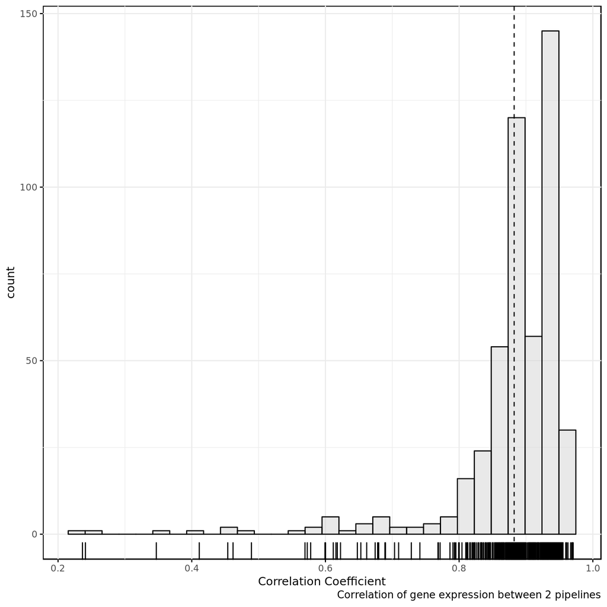

```r
# correlation
mcor <- cor(mat1.log2, mat2.log2)
cxy <- diag(mcor)
gghistogram(
  cxy,
  fill = "lightgray",
  add = "mean",
  rug = TRUE,
  caption="Correlation of gene expression between 2 pipelines",
  ggtheme = theme_minimal(),
  xlab = "Correlation Coefficient"
) + border()
```

# SNN Clustering

We use Shared Nearest Neighbors (SNN) clustering algorithm to cluster the single cell. R function ‘buildSNNGraph()’ is applied to log2 transformed data matrix and vector of membership is returned.

## Run SNN clustering

The function RunClustering() will build up a graph structure by calling buildSNNGraph() and then apply cluster_fast_greedy() function to make clustering calls.

```r
mat1.snn <- RunClustering(mat1.log2)
mat2.snn <- RunClustering(mat2.log2)
```

## Visualize SNN clustering

Here we will visualize the known cell type (in meta data) and predict clustering membership is visualized in TSne 2D scatterplot

### Base pipeline results

Form the data frame

```r
df <- data.frame(mat1.snn$tsne$Y,'membership'=as.factor(mat1.snn$clusters$membership) ,'labels'=labels)
```

First we will project gene matrix into Tsne 2-D plot and label cell cells by their known cell types and lineage.

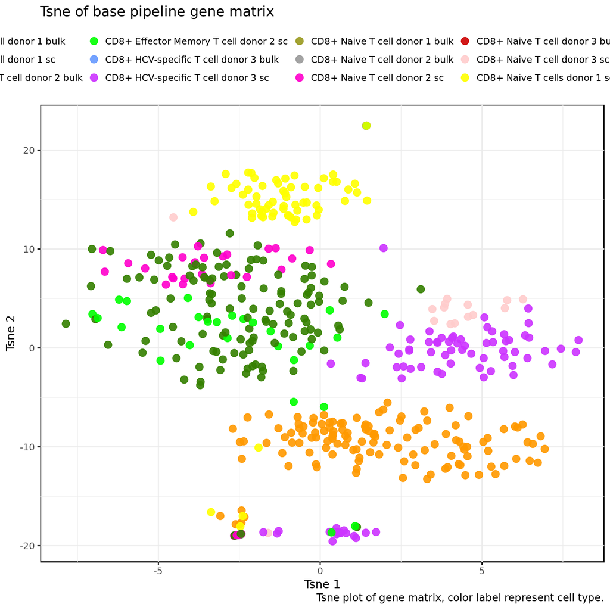

```r
ggscatter(
  df,
  x = "X1",
  y = "X2",
  color = "labels",
  palette = "ucscgb",
  legend = "top",
  size = 3,
  alpha = 0.9,
  caption= "Tsne plot of gene matrix, color label represent cell type.",
  ggtheme = theme_minimal(),
  title = 'Tsne of base pipeline gene matrix'
) + border()+
  xlab('Tsne 1')+
  ylab('Tsne 2')
```

Then we re-label cells by their SNN cluster results. Number in the scatterplot indicates the SNN cluster membership

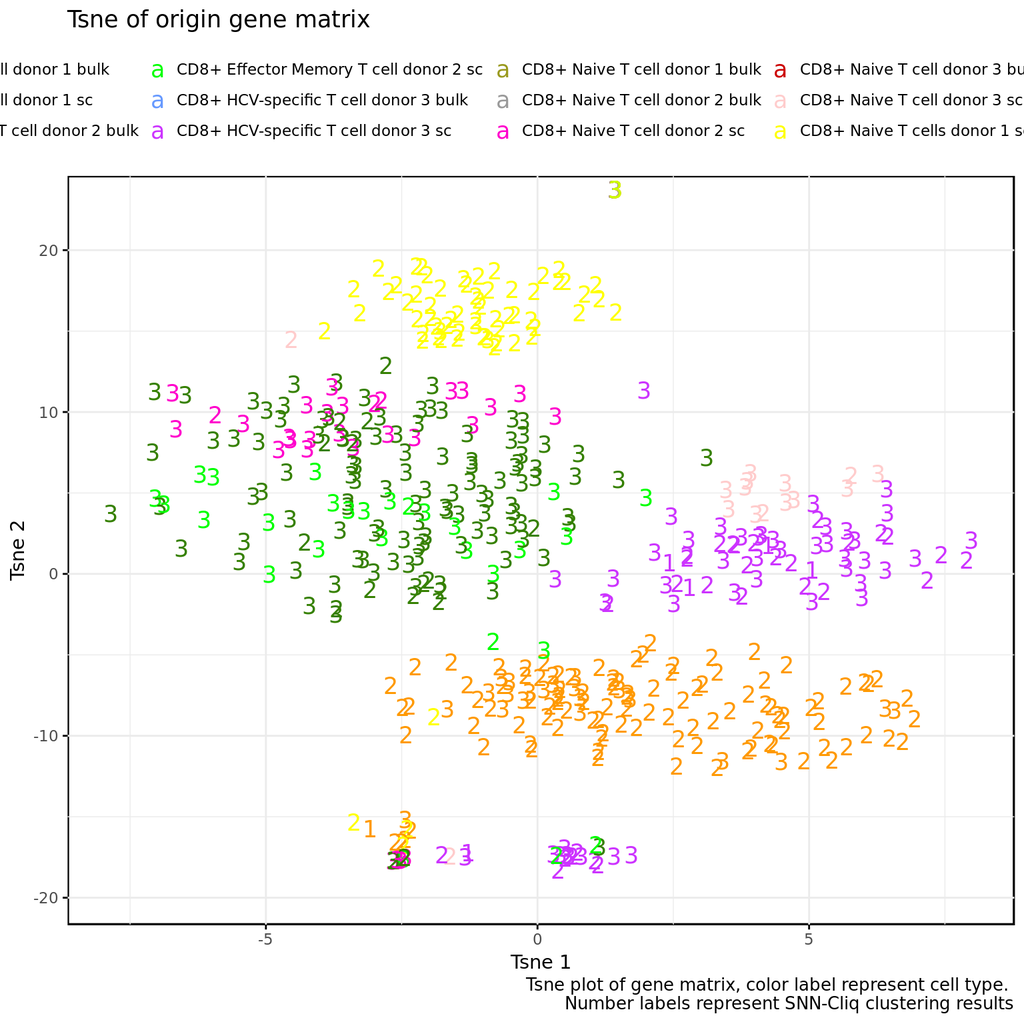

```r
ggscatter(
  df,
  x = "X1",
  y = "X2",
  color = "labels",
  point =F,
  label = "membership",
  font.label = 14,
  palette = "ucscgb",
  legend = "top",
  size = 0,
  alpha = 0.9,
  caption = "Tsne plot of gene matrix, color label represent cell type.
  Number labels represent SNN-Cliq clustering results",
  title = "Tsne of origin gene matrix",
  ggtheme = theme_minimal()
) + border()+
  xlab('Tsne 1')+
  ylab('Tsne 2')
```

### Updated Pipeline Results

Form a data frame

```r
df <- data.frame(mat2.snn$tsne$Y,'membership'=as.factor(mat2.snn$clusters$membership) ,'labels'=labels)
```

Here we will project gene matrix into Tsne 2-D plot and label cell cells by their known cell types and lineage.

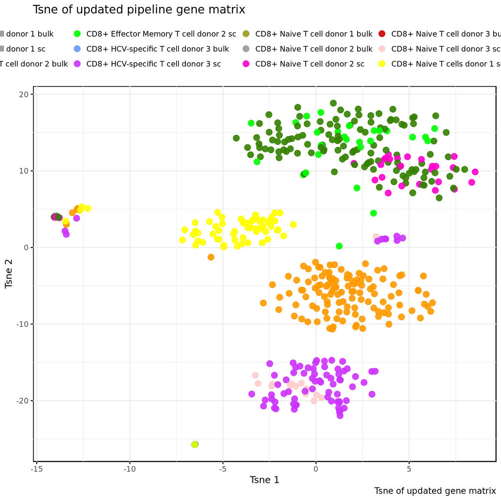

```r
ggscatter(
  df,
  x = "X1",
  y = "X2",
  color = "labels",
  palette = "ucscgb",
  legend="top",
  size = 3,
  alpha = 0.9,
  ggtheme = theme_minimal(),
  caption = "Tsne of updated gene matrix",
  title = 'Tsne of updated pipeline gene matrix'
) + border()+
  xlab('Tsne 1')+
  ylab('Tsne 2')
```

Then we re-label cells by their SNN cluster results. Number in the scatterplot indicates the SNN cluster membership

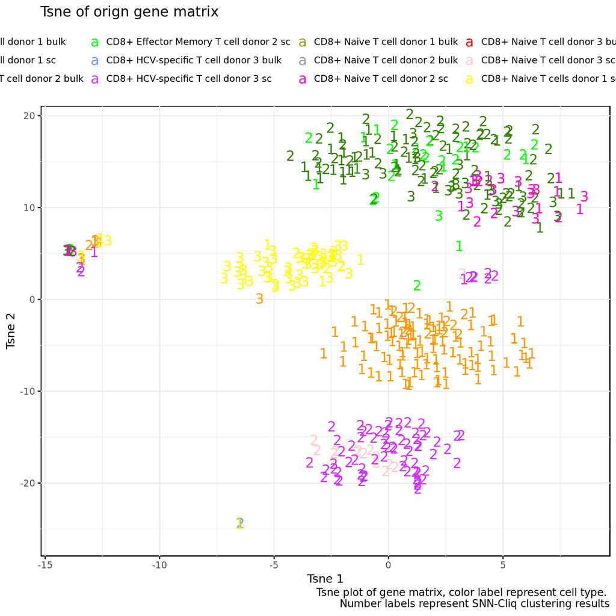

```r
ggscatter(
  df,
  x = "X1",
  y = "X2",
  color = "labels",
  point =F,
  label = "membership",
  font.label = 14,
  palette = "ucscgb",
  legend="top",
  size = 0,
  alpha = 0.9,
  ggtheme = theme_minimal(),
  caption = "Tsne plot of gene matrix, color label represent cell type.
  Number labels represent SNN-Cliq clustering results",
  title = 'Tsne of orign gene matrix'
) + border()+
  xlab('Tsne 1')+
  ylab('Tsne 2')
```

# Compare clustering results

We can compare two clustering results by using compare() function. The function can assesses the distance between two community/clustering structures First let’s look at the membership in clustering results.

## SNN Membership

Pivot table of membership and clustering labels are listed below

### Membership of base pipeline

Pivot table of membership and clustering labels are listed below

```r
knitr::kable(table(mat1.snn$clusters$membership, labels),row.names = T)
```

|  | CD8+ CMV-specific T cell donor 1 bulk | CD8+ CMV-specific T cell donor 1 sc | CD8+ Effector Memory T cell donor 2 bulk | CD8+ Effector Memory T cell donor 2 sc | CD8+ HCV-specific T cell donor 3 bulk | CD8+ HCV-specific T cell donor 3 sc | CD8+ Naive T cell donor 1 bulk | CD8+ Naive T cell donor 2 bulk | CD8+ Naive T cell donor 2 sc | CD8+ Naive T cell donor 3 bulk | CD8+ Naive T cell donor 3 sc | CD8+ Naive T cells donor 1 sc | CD8+ YFV-specific T cell donor 2 bulk | CD8+ YFV-specific T cell donor 2 sc |
| --- | --- | --- | --- | --- | --- | --- | --- | --- | --- | --- | --- | --- | --- | --- |
| 1 | 0 | 1 | 0 | 0 | 0 | 5 | 0 | 0 | 0 | 0 | 0 | 0 | 0 | 0 |
| 2 | 0 | 105 | 0 | 4 | 0 | 29 | 0 | 0 | 3 | 0 | 4 | 61 | 0 | 16 |
| 3 | 1 | 22 | 2 | 26 | 1 | 45 | 1 | 2 | 27 | 1 | 11 | 3 | 2 | 110 |

### Membership of updated pipeline results

Pivot table of membership and clustering labels are listed below

```r
knitr::kable(table(mat2.snn$clusters$membership, labels),row.names = T)
```

|  | CD8+ CMV-specific T cell donor 1 bulk | CD8+ CMV-specific T cell donor 1 sc | CD8+ Effector Memory T cell donor 2 bulk | CD8+ Effector Memory T cell donor 2 sc | CD8+ HCV-specific T cell donor 3 bulk | CD8+ HCV-specific T cell donor 3 sc | CD8+ Naive T cell donor 1 bulk | CD8+ Naive T cell donor 2 bulk | CD8+ Naive T cell donor 2 sc | CD8+ Naive T cell donor 3 bulk | CD8+ Naive T cell donor 3 sc | CD8+ Naive T cells donor 1 sc | CD8+ YFV-specific T cell donor 2 bulk | CD8+ YFV-specific T cell donor 2 sc |
| --- | --- | --- | --- | --- | --- | --- | --- | --- | --- | --- | --- | --- | --- | --- |
| 1 | 1 | 112 | 2 | 9 | 0 | 2 | 1 | 2 | 8 | 1 | 0 | 4 | 2 | 38 |
| 2 | 0 | 12 | 0 | 19 | 1 | 77 | 0 | 0 | 7 | 0 | 15 | 5 | 0 | 68 |
| 3 | 0 | 4 | 0 | 2 | 0 | 0 | 0 | 0 | 15 | 0 | 0 | 55 | 0 | 20 |

## Compare clustering results between pipelines

First, use the normalized mutual information measure(nmi)

```r
compare(mat1.snn$clusters$membership,mat2.snn$clusters$membership,method='nmi')
```

```
## [1] 0.08167412
```

Then try the ‘adjusted.rand’

```r
compare(mat1.snn$clusters$membership,mat2.snn$clusters$membership,method='adjusted.rand')
```

```
## [1] 0.09904718
```

## Compare clustering membership to known cell type labels

Calculate adjusted rand index between clustering results to metadata Rand index of pipeline 1

```r
adjustedRandIndex(mat1.snn$clusters$membership,
                        labels)
```

```
## [1] 0.1749103
```

Rand index of pipeline 2

```r
adjustedRandIndex(mat2.snn$clusters$membership,
                        labels)
```

```
## [1] 0.2674589
```

# Output

```r
grps <-
  merge(mat1.snn$clusters$membership,
        mat2.snn$clusters$membership,
        by = 'row.names',
        suffixes = c(".base", ".updated"))
tsne <-merge(mat1.snn$tsne$Y,
             mat2.snn$tsne$Y,
             by = 'row.names',
             suffixes = c(".base", ".updated"))
out<-merge(tsne,grps,by='Row.names')
write.csv(
  out,
  file = paste(output_name, '_tsne_SNN_cluster_data_matrix_comparison.csv', sep = ''),
  quote = F,
  row.names = T
)
```

If you did everyhing right, above this is the easy part. Simply render the script as desired with the `render` function from `rmarkdown`.  
Rscript -e ‘rmarkdown::render(“Compare_data_matrix.R”)’ -—args “-—matrix1=base_matrix.csv,–matrix2=updated_matrix.csv,–metadata_file=metadata.csv,–output_prefix=output_name”